# TnSeq data analysis for a transposon library in Ralstonia eutropha

Michael Jahn

27 januari, 2021

## Description

This R notebook is a bioinformatics pipeline to map reads from a barcoded transposon library to the genome of a target organism. For background and details regarding the method, see [Wetmore at al., mBio, 2015](https://mbio.asm.org/content/6/3/e00306-15) and [Price et al., Nature, 2018](http://www.nature.com/articles/s41586-018-0124-0)). The initial steps of processing next generation sequencing data was directly adapted from [Morgan Price’s Feba repository](https://bitbucket.org/berkeleylab/feba/src/master/), see also the [TnSeq-pipe github repository](https://github.com/m-jahn/TnSeq-pipe) for an overview.

## Bash pipeline

`Fastq` raw data files were processed as outlined in the documentation for the [TnSeq-pipe github repository](https://github.com/m-jahn/TnSeq-pipe). This step creates the barcode mappings (`data/mapped/*.tsv`) and the summary **pool file** (`data/pool/pool.tsv`). Mapping files from different sequencing runs were combine to one pool file using this standalone perl script from the TnSeq-pipe repo.

```r
perl feba/bin/DesignRandomPool.pl -minN 1 \
  -pool ../R_projects/R-notebook-ralstonia-proteome/data/pool/CN_V2_pool.tsv \
  -genes ref/GCF_000009285.1_ASM928v2_genomic_trimmed.tsv \
  ../R_projects/R-notebook-ralstonia-proteome/data/mapped/*.tsv
```

## Libraries

```r
# optionally install repos from github
# devtools::install_github("m-jahn/lattice-tools")
library(lattice)
library(latticeExtra)
library(latticetools)
library(data.table)
library(MASS)
library(stringi)
library(zoo)
library(tidyverse)
```

## Mapping statistics and distribution on genome

The next step is to inspect basic statistics of transposon insertions and their distribution over the genome.

### Basic statistics

First read in data tables of the barcode ‘pool’, a summary of individual sequencing reads. Barcodes without mapping to the genome are removed. Data from three different sequencing runs were combined in one pool file (`CN_V2_pool.tsv`). A separate pool file contains a different, earlier iteration of the library and therefore a different set of transposon insertions, prepared by Kyle Kimler (`CN_V1_pool.tsv`).

```r
# import seq data from first version of library
df_pool_V1 <- read_tsv("../data/pool/CN_V1_pool.tsv")

# import seq data from second version of library
df_pool_V2 <- read_tsv("../data/pool/CN_V2_pool.tsv")

# combine all in one df, removing duplicate barcodes
df_pool <- bind_rows(df_pool_V1, df_pool_V2, .id = "version") %>%
  arrange(desc(version)) %>% filter(!duplicated(barcode)) %>%
  arrange(version)

# import reference genome
df_ref <- read_tsv("../data/ref/GCF_000009285.1_ASM928v2_genomic_trimmed.tsv") %>%
  filter(!duplicated(old_locus_tag))
```

[output not shown]

Next we can plot the frequency of reads per barcoded transposons.

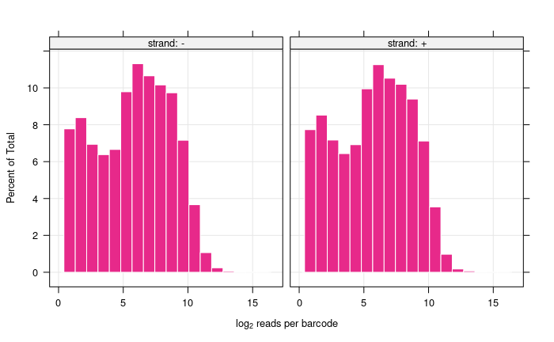

```r
plot_reads_per_bc <- histogram(~ log2(nTot) | paste("strand:", strand), df_pool,
  par.settings = custom.colorblind(),
  between = list(x = 0.5, y = 0.5),
  xlab = expression("log"[2]*" reads per barcode"),
  scales = list(alternating = FALSE),
  panel = function(x, ...) {
    panel.grid(h = -1, v = -1, col = grey(0.9))
    panel.histogram(x, border = "white", ...)
  }
)

print(plot_reads_per_bc)
```

### Distribution over the genome

**Read frequency over genome**

Each transposon insertion is indexed with a position on the genome. We can now plot insertion frequency over the genome. There are different ways to do that depending on how the data is treated. The most simple case (as done below) plotting the number of reads per transposon versus its insertion site on the genome, broken down by chromosome type (‘scaffold’).

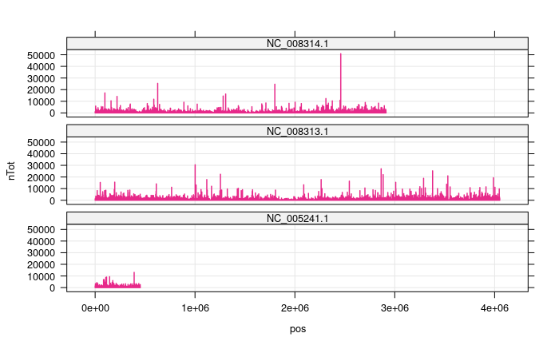

```r
plot_reads_on_genome <- xyplot(nTot ~ pos | scaffold,
  df_pool %>% arrange(pos),
  par.settings = custom.colorblind(),
  between = list(x = 0.5, y = 0.5),
  layout = c(1,3), type = "l", lwd = 1.5,
  scales = list(alternating = FALSE),
  panel = function(x, y, ...) {
    panel.grid(h = -1, v = -1, col = grey(0.9))
    panel.xyplot(x, y, ...)
  }
)

print(plot_reads_on_genome)
```

**Tn insertion frequency over genome**

However this does not really reflect the actual insertion *frequency*. For the frequency, what matters is the number of different, unique insertions per kb of the genome. We can apply a density function or generate a rolling mean to evaluate frequency. Lattice’s `densityplot` scales the frequency per location based on the length of x-axis, so it’s not suitable to compare insertion frequencies between chromosomes of different length.

Instead, we use a defined window of for example 10,000 bp and determine the sum of Tn insertion events per window. Some fo them might be duplicated barcodes because they map to more than one position. However these were still included here since they are often biologically relevant (CBB operon) and are low in number.

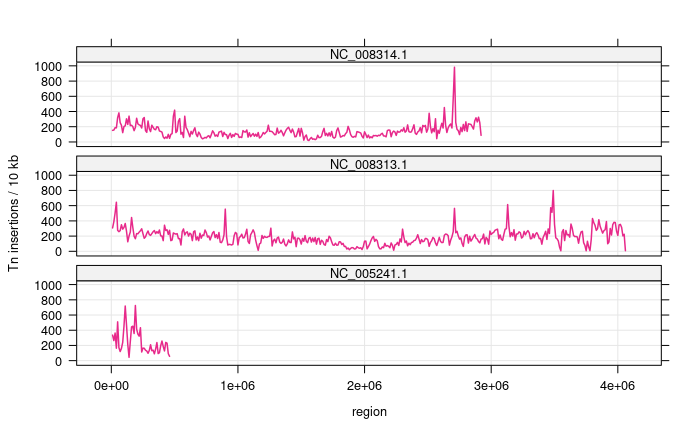

```r
plot_Tns_on_genome <- df_pool %>%
  arrange(pos) %>%
  mutate(region = cut_interval(pos, length = 10000, labels = FALSE)*10000) %>%
  group_by(scaffold, region) %>%
  summarize(tn_per_region = length(barcode)) %>%

  xyplot(tn_per_region ~ region | scaffold, .,
    par.settings = custom.colorblind(),
    ylab = "Tn insertions / 10 kb",
    between = list(x = 0.5, y = 0.5),
    layout = c(1,3), type = "l", lwd = 1.5,
    scales = list(alternating = FALSE),
    panel = function(x, y, ...) {
      panel.grid(h = -1, v = -1, col = grey(0.9))
      panel.xyplot(x, y, ...)
    }
  )

print(plot_Tns_on_genome)
```

### Mapping barcodes to genes

The basic Feba scripts produce a table of barcodes, their frequencies and genomic position information. What we really want to know is **how many transposons/barcodes are mapped to each gene, which position within a gene they have, how many barcodes do not map to a gene (intergenic, low importance), and how many genes were not hit by a transposon (probably essential)**. For this purpose we can use the function `foverlaps()` from package `data.table` to map transposon insertion sites to genes (or vice versa). The following part was inspired by previous work of Kyle Kimler ([github link](https://github.com/kylekimler/)).

```r
# prepare input data in form of data tables
dt_pool <- data.table(df_pool)
dt_ref <- data.table(df_ref)

#dummy begin/end columns are created in the pool file to allow foverlap function
dt_pool$begin <- dt_pool$pos
dt_pool$end <- dt_pool$pos

# map Tn insertion sites to genes
setkey(dt_ref, scaffold, begin, end)
df_pool_annotated <- foverlaps(dt_pool, dt_ref,
    by.x = c("scaffold", "begin", "end"), type = "within") %>%
  as_tibble %>%
  select(barcode, rcbarcode, nTot, n, scaffold, i.strand, pos, begin,
    end, strand, desc, old_locus_tag, new_locus_tag, version) %>%
  rename(gene_strand = strand, strand = i.strand) %>%
  # exclude alternative mappings in case of overlapping genes
  filter(!duplicated(barcode)) %>%
  # include also unhit genes in main table
  full_join(df_ref)

head(df_pool_annotated)
```

| barcode | rcbarcode | nTot | n | scaffold | strand | pos | begin | end | gene_strand | desc | old_locus_tag | new_locus_tag | version |
| --- | --- | --- | --- | --- | --- | --- | --- | --- | --- | --- | --- | --- | --- |
| GGTAATTGGGGCAAAGTGAG | CTCACTTTGCCCCAATTACC | 320 | 310 | NC_008313.1 | - | 1185600 | 1185079 | 1185921 | + | gene | H16_A1089 | H16_RS05415 | 1 |
| CCCGGGTGGCAAGTCTGACG | CGTCAGACTTGCCACCCGGG | 906 | 890 | NC_008314.1 | - | 621156 | 620617 | 621561 | + | gene | H16_B0551 | H16_RS21480 | 1 |
| CAAAATTGAGTTGGGATTGG | CCAATCCCAACTCAATTTTG | 62 | 60 | NC_008313.1 | - | 1672632 | 1672375 | 1673157 | + | gene | H16_A1538 | H16_RS07640 | 1 |
| CAGATGACAGCAAGGGGTCC | GGACCCCTTGCTGTCATCTG | 2681 | 2624 | NC_008314.1 | - | 352046 | 350476 | 352278 | - | gene | H16_B0315 | H16_RS20315 | 1 |
| CGGACGATATGGGTAGCTGA | TCAGCTACCCATATCGTCCG | 54 | 52 | NC_008313.1 | - | 3113457 | 3112440 | 3113825 | - | gene | H16_A2885 | H16_RS14375 | 1 |
| ATAGGTTAGAACATTGAGGG | CCCTCAATGTTCTAACCTAT | 375 | 368 | NC_008314.1 | + | 531922 | NA | NA | NA | NA | NA | NA | 1 |

### Gene insertion frequency

Now that all transposons are mapped to genes (if possible), we can calculate basic statistics about how many genes were hit, how many transposons inserted in a gene on average, and how many transposons hit intergenic regions.

**Barcodes per gene type**

```r
df_pool_annotated %>%
  group_by(desc) %>%
  summarize(n_barcodes = sum(!is.na(barcode))) %>%
  mutate(desc = replace_na(desc, "intergenic")) %>%
  arrange(desc(n_barcodes))
```

| desc | n_barcodes |
| --- | --- |
| gene | 106144 |
| intergenic | 21772 |
| pseudogene | 1567 |

**Insertions per gene**

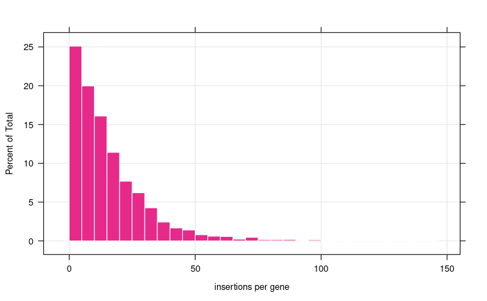

```r
df_pool_annotated <- df_pool_annotated %>%
  group_by(old_locus_tag) %>%
  mutate(tn_per_gene = sum(!is.na(barcode))) %>%
  mutate(tn_per_gene = case_when(
    is.na(old_locus_tag) ~ 0,
     TRUE ~ as.numeric(tn_per_gene[1]))
  )

plot_insertions_per_gene <- df_pool_annotated %>%
  summarize(tn_per_gene = tn_per_gene[1]) %>%
  filter(tn_per_gene < 150) %>%

  histogram( ~ tn_per_gene, .,
    par.settings = custom.colorblind(), border = "white",
    breaks = 40, xlab = "insertions per gene",
    panel = function(x, ...) {
      panel.grid(h = -1, v = -1, col = grey(0.9))
      panel.histogram(x, ...)
    }
  )

print(plot_insertions_per_gene)
```

**Top 10 genes by number of Tn insertions**

```r
df_pool_annotated %>%
  summarize(tn_per_gene = tn_per_gene[1]) %>%
  arrange(desc(tn_per_gene)) %>% slice(1:10)
```

| old_locus_tag | tn_per_gene |
| --- | --- |
| H16_B2391 | 265 |
| H16_A3231 | 260 |
| H16_A3676 | 245 |
| H16_B0247 | 201 |
| H16_A3631 | 177 |
| H16_B0434 | 175 |
| H16_A0740 | 167 |
| H16_B2313 | 167 |
| PHG107 | 160 |
| H16_A0822 | 151 |

### Position of transposons within a gene

The mapping of a transposon to a gene also reveals its relative position within the gene. We can use this information to tag insertions as more likely to have a fitness effect, or not. We can also filter out transposons that lie outside the central portion of a gene (e.g. 10% margin to each side), or within a fixed flanking region (e.g. first or last 100 bp). The original FEBA protocol from Morgan Price uses a quality filter that requires transposons be located within the central 80% of a gene. We follow this definition and flag transposon outside the central portion of a gene as unreliable.

```r
# apply margin of 10% gene length
df_pool_annotated <- df_pool_annotated %>% ungroup %>%
  mutate(
    gene_length = end-begin,
    pos_relative = (pos-begin)/(end-begin),
    central = dplyr::between(pos_relative, 0.1, 0.9)
  )
```

How many transposons that inserted into a gene are central? We can summarize, and find that around 80% are central.

```r
df_pool_annotated %>%
  filter(!is.na(central)) %>%
  group_by(central) %>%
  summarize(frequency = length(pos)) %>%
  mutate(percent = frequency/sum(frequency)*100)
```

| central | frequency | percent |
| --- | --- | --- |
| FALSE | 22949 | 21.30609 |
| TRUE | 84762 | 78.69391 |

How are insertions distributed over each gene, measured in relative position from 0 to 1? There is a trend towards higher insertion frequency at the termini of genes. Otherwise the insertion frequency is homogeneously distributed.

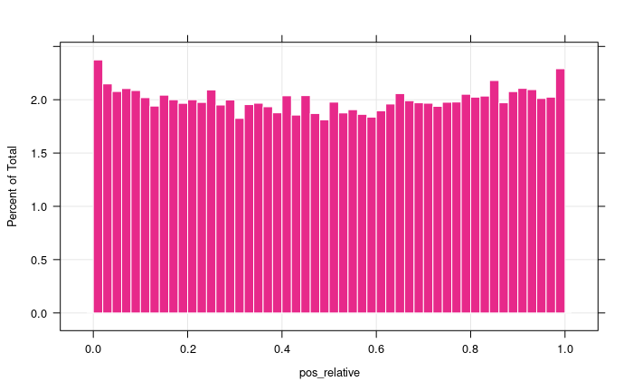

```r
plot_insertion_position <- df_pool_annotated %>%
  filter(!is.na(central)) %>%

  histogram( ~ pos_relative, .,
  par.settings = custom.colorblind(),
  breaks = 50,
  panel = function(x, ...) {
    panel.grid(h = -1, v = -1, col = grey(0.9))
    panel.histogram(x, border = "white", ...)
  }
)

print(plot_insertion_position)
```

## Gene essentiality analysis

### Insertion index and insertion probability

#### Insertion index

We can estimate gene essentiality from the average frequency of transposon insertions per region, and the specific number of transposon insertions for a gene. Transposons integrate with a certain probability into the genome, and this probability depends on the distance to the origin of replication on a chromosome. Following the protocol from Rubin et al., PNAS, 2015 for a Tn library in *Synechococcus*, an **insertion index** is calculated that is a measure of essentiality. This index is the insertion frequency per gene divided by frequency per region (average of e.g. 100 genes).

*I = (tn_gene / length_gene) / (tn_region / length_region)*

with *tn_gene* and *length_gene* being the number of transposons inserted per gene, normalized by length. This is then compared to the average insertion frequency for a region/window with e.g. 10,000 bp width.

#### Insertion probability

Random transposon insertion into the genome resembles the random drawing of balls from an urn, with replacement. The transposon can integrate at the position multiple times (= recycling of positions). To estimate the **probability of the observed number of insertions**, we can apply the binomial distribution (*without* replacement it would be the hypergeometric distribution). The number of total available insertion positions is a window of 10,000 bp around a gene. The single probability of transposon insertion into a gene is the length of the gene divided by length of the window (e.g. 1,000 bp/10,000 bp). The number of samples drawn is the actual number of Tn insertions in this window, e.g. 300. The probability `P(x)` of Tn insertion into the gene at a rate x = 0 (exactly no insertion) is then:

*P(x=0) = pbinom(x, sum of Tn insertions = 300, single probability = 1000/10000) = 1.873928e-14*

These two terms are eqivalent: `dbinom()` gives the density function, i.e. probability for the exact event `P(X = x)`. `pbinom()` gives the distribution function, that means the *sum of the probabilities* for all events `P[X ≤ x]` in case of `lower.tail = TRUE` (the default).

```r
sum(dbinom(0:10, 300, 1000/10000))
```

```
[1] 1.068376e-05
```

```r
pbinom(10, 300, 1000/10000)
```

```
[1] 1.068376e-05
```

Now we determine insertion index and insertion probability for the TnSeq data.

```r
len_interval = 50000

# calculate the ratio of insertion frequency per gene and per region
df_pool_annotated <- df_pool_annotated %>%

  # Construct intervals spanning 10 kb
  mutate(pos = if_else(is.na(pos), round(begin+(end-begin)/2), pos)) %>%
  group_by(scaffold) %>% arrange(pos) %>%
  mutate(length_interval = cut_interval(pos, length = len_interval)) %>%
  group_by(scaffold, length_interval) %>%
  mutate(length_interval = length(pos)) %>%

  # determine CENTRAL insertions per flanking interval,
  # as sum over a rolling window
  group_by(scaffold) %>%
  mutate(tn_interval = zoo::rollapply(central,
    FUN = function(x){sum(x, na.rm = TRUE)},
    width = length_interval, fill = NA, partial = TRUE)) %>%

  # finally determine insertion index
  group_by(old_locus_tag) %>%
  mutate(insertion_index = median(na.rm = TRUE,
    (sum(central, na.rm = TRUE) / gene_length) / (tn_interval / len_interval)
  ) %>% replace_na(0) %>% replace(., . > 100, NA)) %>%

  # and probability of observed number of insertions or lower P(X <= x)
  mutate(insertion_probability =
    pbinom(sum(central, na.rm = TRUE), round(mean(tn_interval, na.rm = TRUE)), mean(gene_length)*0.8/len_interval)
  )
```

Now we can plot distribution of insertion indices, and insertion probabilities.

```r
plot_ii_hist <- df_pool_annotated %>% slice(1) %>%
  filter(insertion_index < 3) %>%
  histogram( ~ insertion_index, .,
    par.settings = custom.colorblind(),
    breaks = 30,
    panel = function(x, ...) {
      panel.grid(h = -1, v = -1, col = grey(0.9))
      panel.histogram(x, border = "white", ...)
    }
  )

plot_ip_hist <- df_pool_annotated %>% slice(1) %>%
  histogram( ~ insertion_probability, .,
    par.settings = custom.colorblind(),
    breaks = 30,
    panel = function(x, ...) {
      panel.grid(h = -1, v = -1, col = grey(0.9))
      panel.histogram(x, border = "white", ...)
    }
  )

plot_ii_vs_ip <- df_pool_annotated %>% slice(1) %>%
  xyplot(log10(insertion_probability) ~ log10(insertion_index), .,
    par.settings = custom.colorblind(), pch = 19, alpha = 0.3,
    panel = function(x, y, ...) {
      panel.grid(h = -1, v = -1, col = grey(0.9))
      panel.xyplot(x, y, ...)
    }
  )

print(plot_ii_hist, split = c(1,1,3,1), more = TRUE)
print(plot_ip_hist, split = c(2,1,3,1), more = TRUE)
```

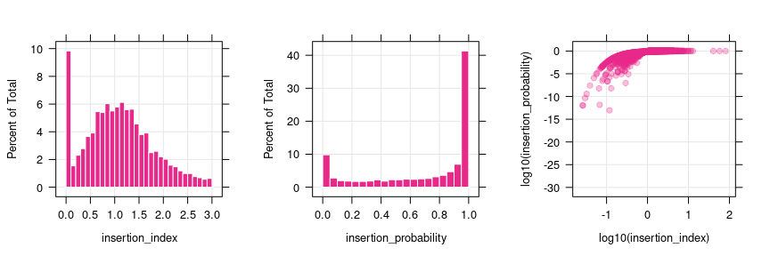

```r
print(plot_ii_vs_ip, split = c(3,1,3,1))
```

### Predicitng essentiality from insertion index distribution

```r
# function to fit two gamma distributions to insertion index (II) distribution
# and identify thresholds for essential, ambiguous, and non-essential genes
find_essential <- function(ins_index, prob_ratio = 5) {

  # identify second maxima
  h <- hist(ins_index, breaks = 200, plot = FALSE)
  maxindex <- which.max(h$density[10:length(h$density)])
  maxval <- h$mids[maxindex+3]

  # find inter-mode minimum insertion index with loess
  hist_min <- hist(ins_index[ins_index < maxval],
      breaks = seq(0, maxval, by = maxval/2000), plot = FALSE)
  lo <- loess(hist_min$density ~ c(1:2000))
  local_min = hist_min$mids[which.min(predict(lo))]

  # fraction of values assigned to each distribution
  f1 = (sum(ins_index < local_min) + sum(ins_index == 0))/length(ins_index)
  f2 = (sum(ins_index >= local_min))/length(ins_index)

  # fit 1) exponential function to II of essential genes
  # fit 2) gamma distribution to II of nonessential genes
  d1 = fitdistr(ins_index[ins_index < local_min], "exponential")
  d2 = fitdistr(ins_index[ins_index >= local_min], "gamma") %>% suppressWarnings()

  # plots
  ii_range <- seq(0, round(max(ins_index), 1), length.out = 1000)
  fit_essential <- f1*dgamma(ii_range, 1, d1$estimate[1])
  fit_non_essential <- f2*dgamma(ii_range, d2$estimate[1], d2$estimate[2])

  # given the two probability density functions,
  # we can determine the probability of an event falling into one or the other category
  # for example, we can determine a threshold for the II where the probability of
  # falling into one category is much (5x) higher than of falling into the other
  p1 <- f1*dgamma(ii_range, 1, d1$estimate[1])
  p2 <- f2*dgamma(ii_range, d2$estimate[1], d2$estimate[2])
  ambiguous <- ii_range[which((p1 < prob_ratio*p2) & (p2 < prob_ratio*p1))]

  # return list of results
  list(
    lower_t = ambiguous[1],
    upper_t = tail(ambiguous, 1),
    ii_range = ii_range,
    fit_essential = fit_essential,
    fit_non_essential = fit_non_essential
  )
}
```

After adapting the function, we run it with the insertion index for all genes as input and obtain the fitted density functions, and the thresholds for ambiguous genes.

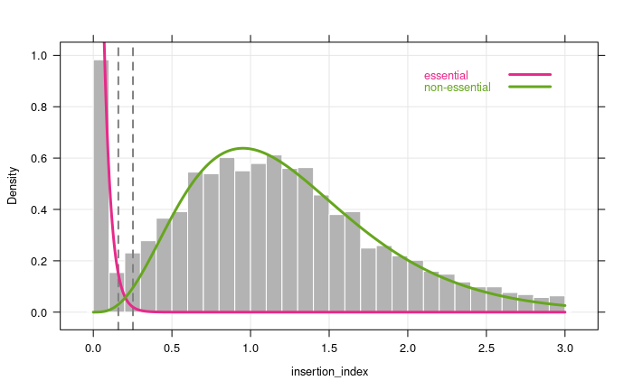

```r
# run function with II
essential <- summarize(df_pool_annotated, ii = insertion_index[1]) %>%
  filter(ii < 3) %>% pull(ii) %>%
  find_essential

# and plot the results on an II histogram with overlaid probability
# density function
df_pool_annotated %>%
  summarize(insertion_index = insertion_index[1]) %>%
  filter(insertion_index < 3) %>%

  histogram( ~ insertion_index, .,
    par.settings = custom.colorblind(),
    breaks = 30, col = grey(0.7),
    type = "density",
    panel = function(x, ...) {
      panel.grid(h = -1, v = -1, col = grey(0.9))
      panel.histogram(x, border = "white", ...)
      panel.key(labels = c("essential", "non-essential"), points = FALSE,
        lines = TRUE, lwd = 3, corner = c(0.9, 0.9))
      panel.abline(v = c(essential$lower_t, essential$upper_t),
        lwd = 2, lty = 2, col = grey(0.5))
    }
  ) + as.layer(
    xyplot(essential$fit_essential + essential$fit_non_essential ~ essential$ii_range,
      type = "l", lwd = 3
    )
  )
```

### Analysis of essential gene set

First and most interesting question: How many genes are essential and non-essential? We can compile a new summary data frame with one gene per row, and add extensive genome annotation to it (compiled from KEGG, eggNOG COG, uniprot).

```r
# summarize information per gene
df_essential <- df_pool_annotated %>%
  rename(locus_tag = old_locus_tag) %>%
  group_by(locus_tag) %>%
  summarize(
    n_barcodes = sum(!is.na(barcode)),
    n_barcodes_central = sum(central, na.rm = TRUE),
    scaffold = scaffold[1],
    begin = begin[1],
    end = end[1],
    gene_strand = gene_strand[1],
    desc = desc[1],
    insertion_index = insertion_index[1],
    insertion_probability = insertion_probability[1],
    tn_interval = mean(tn_interval, na.rm = TRUE)
  ) %>%

  # add verdict about essentiality to each locus
  mutate(
    essentiality = case_when(
      insertion_index <= essential$lower_t ~ "essential",
      insertion_index <= essential$upper_t & insertion_index > essential$lower_t ~ "ambiguous",
      insertion_index > essential$upper_t ~ "non-essential"
    )
  ) %>%

  # optional filtering of false-positive 'essential' genes that were probably not hit
  # due to low tn_interval insertion frequency
  mutate(
    essentiality = case_when(
      insertion_probability >= 0.1 & essentiality == "essential" ~ "ambiguous",
      TRUE ~ essentiality
    )
  ) %>%

  # merge with genome annotation for R.e.
  left_join(read_csv("../data/ref/Ralstonia_H16_genome_annotation.csv"))

head(df_essential)
```

| locus_tag | n_barcodes | n_barcodes_central | scaffold | begin | end | gene_strand | desc | insertion_index | insertion_probability | tn_interval | essentiality | uniprot | protein | protein_name | gene_name | length | EC_number | gene_ontology_IDs | System | Process | Pathway | COG | COG_ID | COG_System | COG_Process | eggNOG_name | eggNOG_description | new_locus_tag | product_accession | … |
| --- | --- | --- | --- | --- | --- | --- | --- | --- | --- | --- | --- | --- | --- | --- | --- | --- | --- | --- | --- | --- | --- | --- | --- | --- | --- | --- | --- | --- | --- | --- |
| H16_A0001 | 2 | 0 | NC_008313.1 | 689 | 2455 | + | gene | 0.000000 | 1.079432e-08 | 640.5000 | essential | Q0KFR8 | DNAA_CUPNH | Chromosomal replication initiator protein DnaA | dnaA H16_A0001 | 588 | NA | GO:0003688; GO:0005524; GO:0005737; GO:0006270; GO:0006275 | Genetic Information Processing | Genetic information processing | DNA replication proteins | COG0593 | L | Information storage and processing | Replication, recombination and repair | dnaA | it binds specifically double-stranded DNA at a 9 bp consensus (dnaA box) 5'-TTATC CA A CA A-3'. DnaA binds to ATP and to acidic phospholipids | H16_RS00005 | WP_011614275.1 | … |
| H16_A0002 | 1 | 0 | NC_008313.1 | 2823 | 3938 | + | gene | 0.000000 | 7.439629e-06 | 656.0000 | essential | Q0KFR7 | Q0KFR7_CUPNH | Beta sliding clamp | dnaN H16_A0002 | 371 | NA | GO:0003677; GO:0003887; GO:0005737; GO:0006260; GO:0008408; GO:0009360 | Genetic Information Processing | Genetic information processing | DNA replication proteins | COG0592 | L | Information storage and processing | Replication, recombination and repair | dnaN | Confers DNA tethering and processivity to DNA polymerases and other proteins. Acts as a clamp, forming a ring around DNA (a reaction catalyzed by the clamp-loading complex) which diffuses in an ATP-in… | H16_RS00010 | WP_010811375.1 | … |
| H16_A0003 | 0 | 0 | NC_008313.1 | 4168 | 6693 | NA | gene | 0.000000 | 1.575679e-12 | 659.0000 | essential | Q0KFR6 | Q0KFR6_CUPNH | DNA gyrase subunit B (EC 5.99.1.3) | gyrB H16_A0003 | 841 | 5.99.1.3 | GO:0003677; GO:0003918; GO:0005524; GO:0005694; GO:0005737; GO:0006261; GO:0006265; GO:0046872 | Genetic Information Processing | Genetic information processing | DNA replication proteins | COG0187 | L | Information storage and processing | Replication, recombination and repair | gyrB | A type II topoisomerase that negatively supercoils closed circular double-stranded (ds) DNA in an ATP-dependent manner to modulate DNA topology and maintain chromosomes in an underwound state. Negativ… | H16_RS00015 | WP_011614276.1 | … |
| H16_A0004 | 145 | 92 | NC_008313.1 | 6960 | 9467 | + | gene | 2.337404 | 1.000000e+00 | 780.6000 | non-essential | Q0KFR5 | Q0KFR5_CUPNH | Type I restriction-modification system methylation subunit | H16_A0004 | 835 | NA | GO:0003677; GO:0006306; GO:0008170 | Cellular Processes | Signaling and cellular processes | Prokaryotic defense system | COG0286 | V | Cellular processes and signaling | Defense mechanisms | hsdM | N-6 DNA Methylase | H16_RS00020 | WP_011614277.1 | … |
| H16_A0005 | 98 | 86 | NC_008313.1 | 9460 | 10728 | + | gene | 3.984920 | 1.000000e+00 | 848.4184 | non-essential | Q0KFR4 | Q0KFR4_CUPNH | Type I restriction-modification system specificity subunit | H16_A0005 | 422 | NA | GO:0003677; GO:0006304 | Cellular Processes | Signaling and cellular processes | Prokaryotic defense system | COG0732 | V | Cellular processes and signaling | Defense mechanisms | NA | Type I restriction modification DNA specificity domain | H16_RS33875 | WP_011614278.1 | … |
| H16_A0006 | 113 | 79 | NC_008313.1 | 10728 | 14048 | + | gene | 1.398072 | 9.999990e-01 | 853.4425 | non-essential | Q0KFR3 | Q0KFR3_CUPNH | Type I restriction enzyme R Protein (EC 3.1.21.3) | H16_A0006 | 1106 | 3.1.21.3 | GO:0003677; GO:0005524; GO:0009035; GO:0009307 | Cellular Processes | Signaling and cellular processes | Prokaryotic defense system | COG0610 | L | Information storage and processing | Replication, recombination and repair | hsdR | Subunit R is required for both nuclease and ATPase activities, but not for modification | H16_RS00030 | WP_011614279.1 | … |

We can now explore the set of essential genes broken down by functional annotation, and so on.

```r
# overview
df_essential %>% pull(essentiality) %>% table
```

```
.
    ambiguous     essential non-essential
          260           513          5776
```

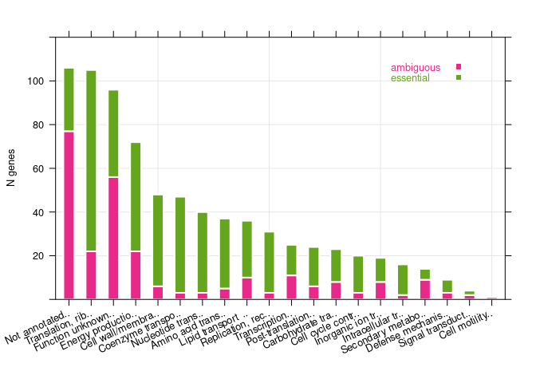

```r
# plot only essential and ambiguous genes sorted by category
df_essential %>% filter(essentiality %in% c("essential", "ambiguous")) %>%
  group_by(COG_Process, essentiality) %>%
  summarize(n_genes = length(locus_tag)) %>%
  mutate(n_genes_tot = sum(n_genes)) %>% ungroup %>%
  arrange(desc(n_genes_tot)) %>%
  mutate(COG_Process = replace_na(COG_Process, "Not annotated") %>%
    substr(1, 16) %>% paste0("..")) %>%

  xyplot(n_genes ~ COG_Process %>% factor(., unique(.)), .,
    par.settings = custom.colorblind(),
    groups = essentiality, ylim = c(0, 120),
    between = list(x = 0.5, y = 0.5), lwd = 2,
    scales = list(alternating = FALSE, x = list(rot = 25)),
    as.table = TRUE, horizontal = FALSE, stack = TRUE,
    border = "white", xlab = "", ylab = "N genes",
    panel = function(x, y, ...) {
      panel.grid(h = -1, v = -1, col = grey(0.9))
      panel.barchart(x, y, ...)
      panel.key(..., corner = c(0.9, 0.9), pch = 15)
    }
  )
```

We can also ‘zoom in’ on different genes of interest. Now it’s gonna be really interesting. We can plot three levels of information for the CBB genes: the locus arrangement, i.e. gene map, the barcode positions and reads mapped to each position, and finally the verdict of a gene is essential or not (probably also insertion index).

This plot shows TN insertions for the **CBB operon on the megaplasmid**.

```r
plots_cbb_mp <- plot_tn_insertions(chromosome = "NC_005241.1",
  start_bp = 435000, end_bp = 451000)

print(plots_cbb_mp[[3]], position = c(0,0.6,1,1), more = TRUE)
print(plots_cbb_mp[[2]], position = c(0,0.35,1,0.75), more = TRUE)
```

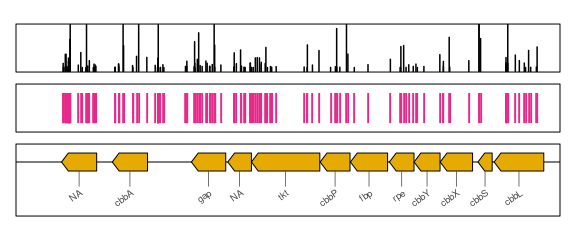

```r
print(plots_cbb_mp[[1]], position = c(0,0,1,0.5))
```

This plot shows the **CBB operon on chromosome 2**.

```r
plots_cbb_mp <- plot_tn_insertions(chromosome = "NC_008314.1",
  start_bp = 1547000, end_bp = 1565000)

print(plots_cbb_mp[[3]], position = c(0,0.6,1,1), more = TRUE)
print(plots_cbb_mp[[2]], position = c(0,0.35,1,0.75), more = TRUE)
```

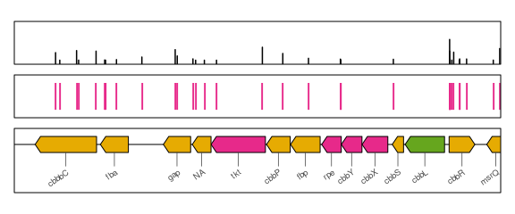

```r
print(plots_cbb_mp[[1]], position = c(0,0,1,0.5))
```

Only one of the genes is labeled as essential, which makes sense, because at least Rubisco was reported before as not being essential. The TnSeq data was obtained with a library grown on LB complete medium, where Calvin cycle genes should not be essential. The central region of chromosome 2 is extremely sparse with Tn insertions. This is a zoomed out version of the previous plot.

```r
plots_cbb_mp_out <- plot_tn_insertions(chromosome = "NC_008314.1",
  start_bp = 1525000, end_bp = 1580000)

print(plots_cbb_mp_out[[3]], position = c(0,0.6,1,1), more = TRUE)
print(plots_cbb_mp_out[[2]], position = c(0,0.35,1,0.75), more = TRUE)
```

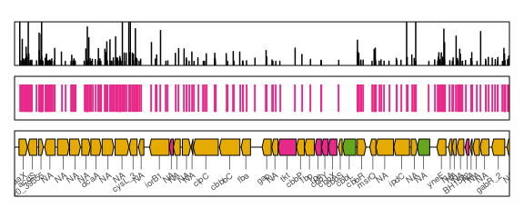

```r
print(plots_cbb_mp_out[[1]], position = c(0,0,1,0.5))
```

Finally we can also examine genes/operons that are labeled as essential, such as DNA replication proteins DnaA, DnaN, gyrB (gyrase).

```r
plots_cbb_mp <- plot_tn_insertions(chromosome = "NC_008313.1",
  start_bp = 0, end_bp = 30000)

print(plots_cbb_mp[[3]], position = c(0,0.6,1,1), more = TRUE)
print(plots_cbb_mp[[2]], position = c(0,0.35,1,0.75), more = TRUE)
```

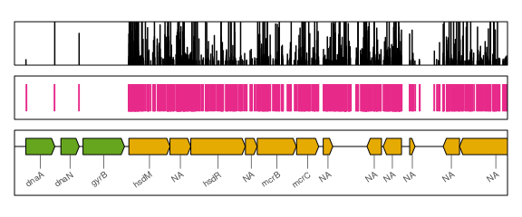

```r
print(plots_cbb_mp[[1]], position = c(0,0,1,0.5))
```

Example for several essential subunits of *gat* operon, the Glutamyl/Aspartyl-tRNA(Gln/Asp) amidotransferase, responsible for ‘charging’ glutaminyl-tRNAs (actually transferring an amino group to a glutamyl-tRNA). Other essential enzymes (subunits) are *mreBCD* involved in cell cycling and DNA maintenance, *mrdAB* involved in petidoglycan synthesis, and *lipAB* involved in lipi biosynthesis.

```r
plots_cbb_mp <- plot_tn_insertions(chromosome = "NC_008313.1",
  start_bp = 110000, end_bp = 145000)

print(plots_cbb_mp[[3]], position = c(0,0.6,1,1), more = TRUE)
print(plots_cbb_mp[[2]], position = c(0,0.35,1,0.75), more = TRUE)
```

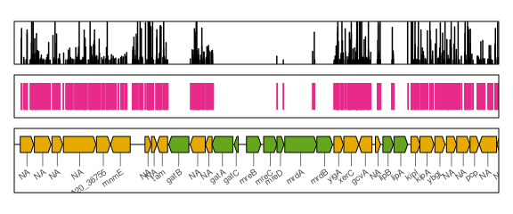

```r
print(plots_cbb_mp[[1]], position = c(0,0,1,0.5))
```

Example for ribosomal proteins on chromosome 1.

```r
plots_cbb_mp <- plot_tn_insertions(chromosome = "NC_008313.1",
  start_bp = 3724000, end_bp = 3758000)

print(plots_cbb_mp[[3]], position = c(0,0.6,1,1), more = TRUE)
print(plots_cbb_mp[[2]], position = c(0,0.35,1,0.75), more = TRUE)
```

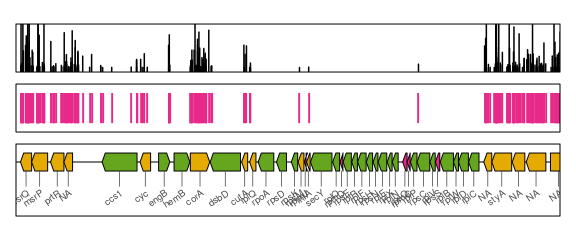

```r
print(plots_cbb_mp[[1]], position = c(0,0,1,0.5))
```

### Comparison with genome scale model

Genes were labeled according to three categories with the help of the TnSeq analysis: 1) `essential` for genes with very few or no transposon insertions, 2) `non-essential` for genes that were hit according to average insertion frequency, and 3) `ambiguous` for genes that could fall in both categories.

THe following analysis compares essentiality from TnSeq results with essentiality for the LB (complete) medium condition as predicted by the genome scale model. We will rughly look at the following four categories:

- not essential in model, not in barseq (`TRUE NEGATIVE`)
- essential in model, but not in barseq (`FALSE POSITIVE`)
- not essential in model, but in barseq (`FALSE NEGATIVE`)
- essential in model, and in barseq (`TRUE POSITIVE`)

The first task is to import model predictions for gene essentiality.

```r
df_model <- read_csv("../data/input/model_gene_essentiality.csv") %>%
  select(-X1) %>% rename(locus_tag = gene)
```

```r
df_essential <- df_model %>% group_by(locus_tag) %>%
  summarize(model_essential = max(as.integer(LB_medium))) %>%
  right_join(df_essential)

df_essential %>%
  filter(!is.na(essentiality), !is.na(model_essential)) %>%
  group_by(essentiality) %>%
  summarize(
    mod_essential = sum(model_essential == 1),
    mod_non_essential = sum(model_essential == 0)
  )
```

| essentiality | mod_essential | mod_non_essential |
| --- | --- | --- |
| ambiguous | 2 | 45 |
| essential | 71 | 151 |
| non-essential | 28 | 1015 |

We can have a closer look at the overlapping set of genes (True positives), and on the set of genes that is essential according to the data, but not according to the model (False negatives). The table is arranged with True positives first, then false negatives.

```r
df_essential %>%
  filter(essentiality == "essential", !is.na(model_essential)) %>%
  arrange(desc(model_essential), desc(tn_interval))
```

| locus_tag | model_essential | n_barcodes | n_barcodes_central | scaffold | begin | end | gene_strand | desc | insertion_index | insertion_probability | tn_interval | essentiality | uniprot | protein | protein_name | gene_name | length | EC_number | gene_ontology_IDs | System | Process | Pathway | COG | COG_ID | COG_System | COG_Process | eggNOG_name | eggNOG_description | new_locus_tag | … |
| --- | --- | --- | --- | --- | --- | --- | --- | --- | --- | --- | --- | --- | --- | --- | --- | --- | --- | --- | --- | --- | --- | --- | --- | --- | --- | --- | --- | --- | --- | --- |
| H16_A3235 | 1 | 0 | 0 | NC_008313.1 | 3493479 | 3496412 | NA | gene | 0.00000000 | 1.110184e-30 | 1435.0000 | essential | Q0K6R1 | Q0K6R1_CUPNH | Ribonucleoside-diphosphate reductase (EC 1.17.4.1) | nrdA H16_A3235 | 977 | 1.17.4.1 | GO:0004748; GO:0005524; GO:0006260 | Genetic Information Processing | Genetic information processing | DNA repair and recombination proteins | COG0209 | F | Metabolism | Nucleotide transport and metabolism | nrdA | Provides the precursors necessary for DNA synthesis. Catalyzes the biosynthesis of deoxyribonucleotides from the corresponding ribonucleotides | H16_RS16115 | … |
| H16_A3234 | 1 | 3 | 0 | NC_008313.1 | 3492021 | 3493208 | - | gene | 0.00000000 | 1.308361e-12 | 1427.0000 | essential | Q0K6R2 | Q0K6R2_CUPNH | Ribonucleoside-diphosphate reductase subunit beta (EC 1.17.4.1) | nrdB H16_A3234 | 395 | 1.17.4.1 | GO:0004748; GO:0006260; GO:0009263; GO:0016021; GO:0046872 | Genetic Information Processing | Genetic information processing | DNA repair and recombination proteins | COG0208 | F | Metabolism | Nucleotide transport and metabolism | nrdB | Provides the precursors necessary for DNA synthesis. Catalyzes the biosynthesis of deoxyribonucleotides from the corresponding ribonucleotides | H16_RS16110 | … |
| H16_A2883 | 1 | 0 | 0 | NC_008313.1 | 3110064 | 3111353 | NA | gene | 0.00000000 | 1.018664e-12 | 1325.0000 | essential | Q0K7R2 | Q0K7R2_CUPNH | 3-Deoxy-D-manno-octulosonic-acid transferase (EC 2.4.99.-) | kdtA H16_A2883 | 429 | 2.4.99.- | GO:0016757 | Metabolism | Glycan biosynthesis and metabolism | Lipopolysaccharide biosynthesis | COG1519 | M | Cellular processes and signaling | Cell wall/membrane/envelope biogenesis | kdtA | transferase | H16_RS14365 | … |
| H16_A2802 | 1 | 0 | 0 | NC_008313.1 | 3030586 | 3031224 | NA | gene | 0.00000000 | 7.102439e-05 | 931.0000 | essential | Q0K7Z0 | PDXH_CUPNH | Pyridoxine/pyridoxamine 5'-phosphate oxidase (EC 1.4.3.5) (PNP/PMP oxidase) (PNPOx) (Pyridoxal 5'-phosphate synthase) | pdxH H16_A2802 | 212 | 1.4.3.5 | GO:0004733; GO:0008615; GO:0010181 | Metabolism | Metabolism of cofactors and vitamins | Vitamin B6 metabolism | COG0259 | H | Metabolism | Coenzyme transport and metabolism | pdxH | Catalyzes the oxidation of either pyridoxine 5'- phosphate (PNP) or pyridoxamine 5'-phosphate (PMP) into pyridoxal 5'-phosphate (PLP) | H16_RS13970 | … |
| H16_A0136 | 1 | 1 | 0 | NC_008313.1 | 149536 | 150378 | + | gene | 0.00000000 | 5.272745e-06 | 896.0000 | essential | Q0KFD3 | Q0KFD3_CUPNH | Type III pantothenate kinase (EC 2.7.1.33) (PanK-III) (Pantothenic acid kinase) | coaX H16_A0136 | 280 | 2.7.1.33 | GO:0004594; GO:0005524; GO:0005737; GO:0015937 | Metabolism | Metabolism of cofactors and vitamins | Pantothenate and CoA biosynthesis | COG1521 | F | Metabolism | Nucleotide transport and metabolism | coaX | Catalyzes the phosphorylation of pantothenate (Pan), the first step in CoA biosynthesis | H16_RS00650 | … |
| H16_A0391 | 1 | 4 | 2 | NC_008313.1 | 408155 | 409138 | - | gene | 0.12168588 | 1.815951e-04 | 836.0000 | essential | Q0KEN0 | Q0KEN0_CUPNH | Predicted sugar phosphate isomerase involved in capsule formation (EC 5.3.1.-) | gutQ H16_A0391 | 333 | 5.3.1.- | GO:0005975; GO:0016853; GO:0046872; GO:0097367; GO:1901135 | Metabolism | Glycan biosynthesis and metabolism | Lipopolysaccharide biosynthesis | COG0517 | M | Cellular processes and signaling | Cell wall/membrane/envelope biogenesis | kdsD | Belongs to the SIS family. GutQ KpsF subfamily | H16_RS01920 | … |
| H16_A3045 | 1 | 2 | 0 | NC_008313.1 | 3296990 | 3297985 | + | gene | 0.00000000 | 1.539424e-06 | 833.5000 | essential | Q0K7A1 | Q0K7A1_CUPNH | FAD Synthase | H16_A3045 | 381 | NA | GO:0003919; GO:0008531; GO:0009231 | Metabolism | Metabolism of cofactors and vitamins | Riboflavin metabolism | COG0196 | H | Metabolism | Coenzyme transport and metabolism | ribF | Belongs to the ribF family | H16_RS15180 | … |
| H16_A0330 | 1 | 1 | 0 | NC_008313.1 | 351230 | 351994 | - | gene | 0.00000000 | 3.824323e-05 | 827.0000 | essential | Q0KEU0 | Q0KEU0_CUPNH | Dinucleotide-utilizing enzyme involved in molybdopterin thiamine biosynthesis family 2 | thiF H16_A0330 | 254 | NA | GO:0008641 | Genetic Information Processing | Folding, sorting and degradation | Sulfur relay system | COG0476 | H | Metabolism | Coenzyme transport and metabolism | moeB | PFAM UBA THIF-type NAD FAD binding protein | H16_RS01625 | … |
| H16_A0367 | 1 | 0 | 0 | NC_008313.1 | 385883 | 386368 | NA | gene | 0.00000000 | 1.681586e-03 | 820.0000 | essential | Q0KEQ3 | COAD_CUPNH | Phosphopantetheine adenylyltransferase (EC 2.7.7.3) (Dephospho-CoA pyrophosphorylase) (Pantetheine-phosphate adenylyltransferase) (PPAT) | coaD H16_A0367 | 161 | 2.7.7.3 | GO:0004595; GO:0005524; GO:0005737; GO:0015937 | Metabolism | Metabolism of cofactors and vitamins | Pantothenate and CoA biosynthesis | COG0669 | F | Metabolism | Nucleotide transport and metabolism | coaD | Reversibly transfers an adenylyl group from ATP to 4'- phosphopantetheine, yielding dephospho-CoA (dPCoA) and pyrophosphate | H16_RS01805 | … |
| H16_A0374 | 1 | 0 | 0 | NC_008313.1 | 391528 | 392406 | NA | gene | 0.00000000 | 1.025385e-05 | 812.0000 | essential | Q0KEP7 | ISPE_CUPNH | 4-diphosphocytidyl-2-C-methyl-D-erythritol kinase (CMK) (EC 2.7.1.148) (4-(cytidine-5'-diphospho)-2-C-methyl-D-erythritol kinase) | ispE H16_A0374 | 292 | 2.7.1.148 | GO:0005524; GO:0016114; GO:0019288; GO:0050515 | Metabolism | Metabolism of terpenoids and polyketides | Terpenoid backbone biosynthesis | COG1947 | F | Metabolism | Nucleotide transport and metabolism | ispE | Catalyzes the phosphorylation of the position 2 hydroxy group of 4-diphosphocytidyl-2C-methyl-D-erythritol | H16_RS01840 | … |

[output cut: 212 more lines]

## Comparison of essentiality with (change in) protein abundance

Essentiality can also be correlated to the MS protein abundance measurements, or the change in protein abundance over conditions. An advanced analysis is also to correlate essentiality or fitness to utilization. First we need to import protein measurements.

```r
load("../data/input/Ralstonia_eutropha.Rdata")
df_prot <- Ralstonia_eutropha; rm(Ralstonia_eutropha)

df_prot <- df_prot %>% left_join(select(df_essential, locus_tag,
  insertion_index, insertion_probability, essentiality))
```

```r
boxplot_colorblind <- custom.colorblind()
boxplot_colorblind$box.rectangle$lwd = 1.5
boxplot_colorblind$box.umbrella$lwd = 1.5

# protein abundance per essentiality group
plot_ess_vs_abund <- df_prot %>% group_by(essentiality, locus_tag) %>%
  summarize(average_mass_g_gDCW = mean(mean_mass_fraction)*0.68) %>%
  xyplot(log10(average_mass_g_gDCW) ~ essentiality %>% factor(., unique(.)[c(2,1,3)]), .,
    par.settings = boxplot_colorblind,
    horizontal = FALSE, do.out = FALSE,
    xlab = "", ylab = expression("m"[protein]*" [log"[10]*" g gDCW"^-1*"]"),
    scales = list(alternating = FALSE, x = list(rot = 25, cex = 0.7)),
    between = list(x = 0.5, y = 0.5),
    panel = function(x, y, ...) {
      panel.grid(h = -1, v = -1, col = grey(0.9))
      panel.violin(x, y, lwd = 0, col = grey(0.6, 0.5), box.width = 0.7, ...)
      panel.bwplot(x, y, pch = "|", box.width = 0.3, ...)
      panel.pvalue(x, y, cex = 0.7, fixed_pos = -0.6, verbose = TRUE, ...)
      panel.text(1:3, -7.3, labels = paste0("n=", table(x)), cex = 0.6)
    }
  )
# CV (relative SD) of protein abundance per essentiality group
plot_ess_vs_change <- df_prot %>% group_by(essentiality, locus_tag) %>%
  summarize(change_mass_g_gDCW = sd(mean_mass_fraction)/mean(mean_mass_fraction)) %>%
  xyplot(log10(change_mass_g_gDCW) ~ essentiality %>% factor(., unique(.)[c(2,1,3)]), .,
    par.settings = boxplot_colorblind,
    horizontal = FALSE, do.out = FALSE,
    xlab = "", ylab = expression("CV m"[protein]*" [log"[10]*"]"),
    scales = list(alternating = FALSE, x = list(rot = 25, cex = 0.7)),
    between = list(x = 0.5, y = 0.5),
    panel = function(x, y, ...) {
      panel.grid(h = -1, v = -1, col = grey(0.9))
      panel.violin(x, y, lwd = 0, col = grey(0.6, 0.5), box.width = 0.7, ...)
      panel.bwplot(x, y, pch = "|", box.width = 0.3, ...)
      panel.pvalue(x, y, cex = 0.7, fixed_pos = 0.9, verbose = TRUE, ...)
      panel.text(1:3, -1.05, labels = paste0("n=", table(x)), cex = 0.6)
    }
  )
print(plot_ess_vs_abund, position = c(0,0,0.5,1), more = TRUE)
```

```
p-value for comparison of  1
 with  essential ambiguous non-essential NA  =  1 5.257024e-08 1.332675e-46
```

```
p-value for comparison of  1
 with  essential ambiguous non-essential NA  =  1 1.05526e-09 2.996163e-37
```

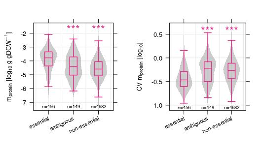

```r
print(plot_ess_vs_change, position = c(0.5,0,1,1))
```

## Export result tables and figures

Export selected tables.

```r
# export simple table with ternary encoding of essential (2), ambiguous (1),
# non-essential genes (0) for mapping with Escher
df_essential %>% filter(!is.na(model_essential)) %>%
  mutate(essentiality = recode(essentiality, "non-essential" = 0, "ambiguous" = 1, "essential" = 2)) %>%
  select(locus_tag, essentiality) %>%
  write_csv("../data/output/essentiality_escher.csv")

# export annotated pool file with V1 of library only
df_pool_annotated %>% filter(!is.na(barcode), version == "2") %>%
  select(-tn_per_gene, -length_interval, -tn_interval,
    -insertion_index, -insertion_probability) %>%
  write_tsv("../data/output/annotated_pool.tsv")
```

Export selected figures to `*.svg` image files.

```r
# to be added
```